# RMarkdown DSC 520 - Project

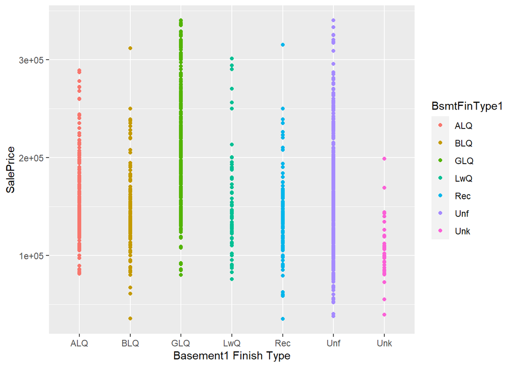

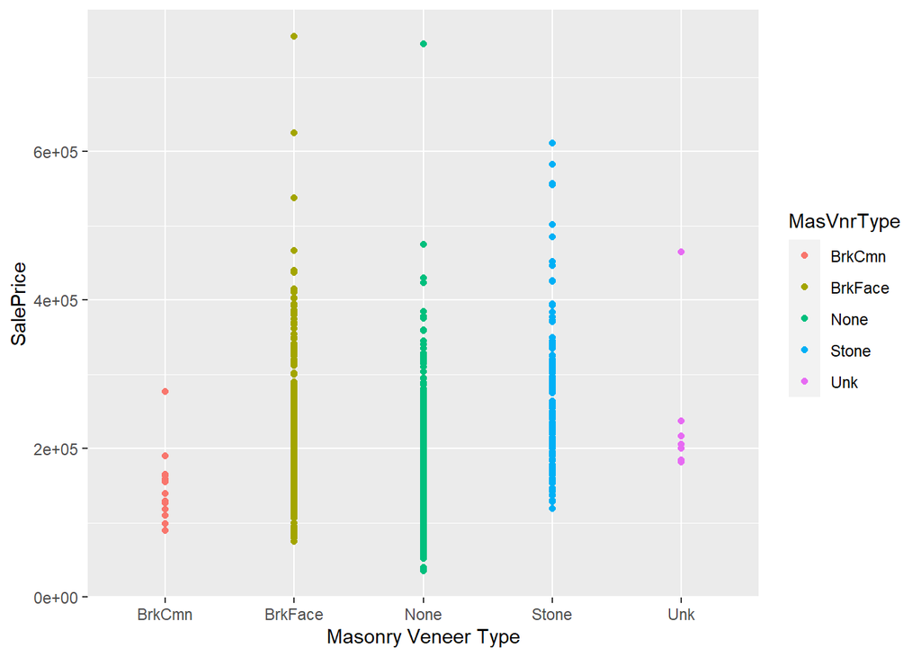

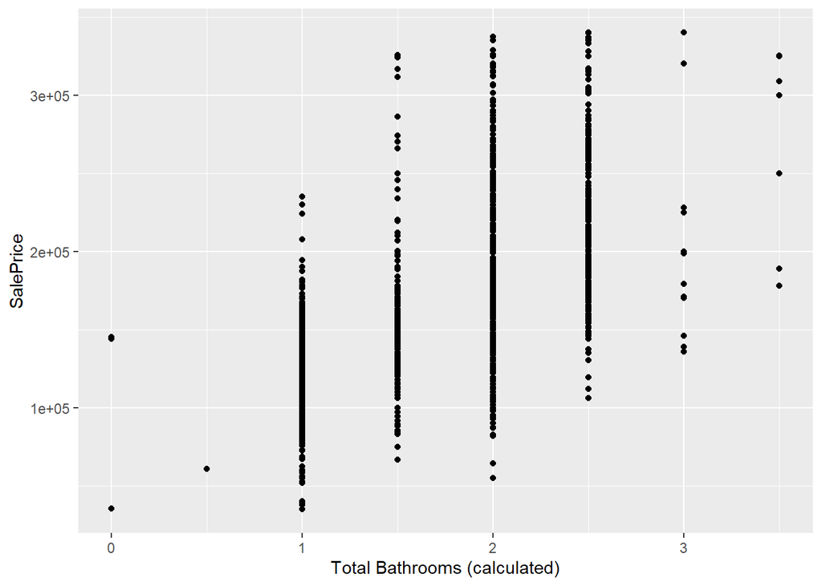

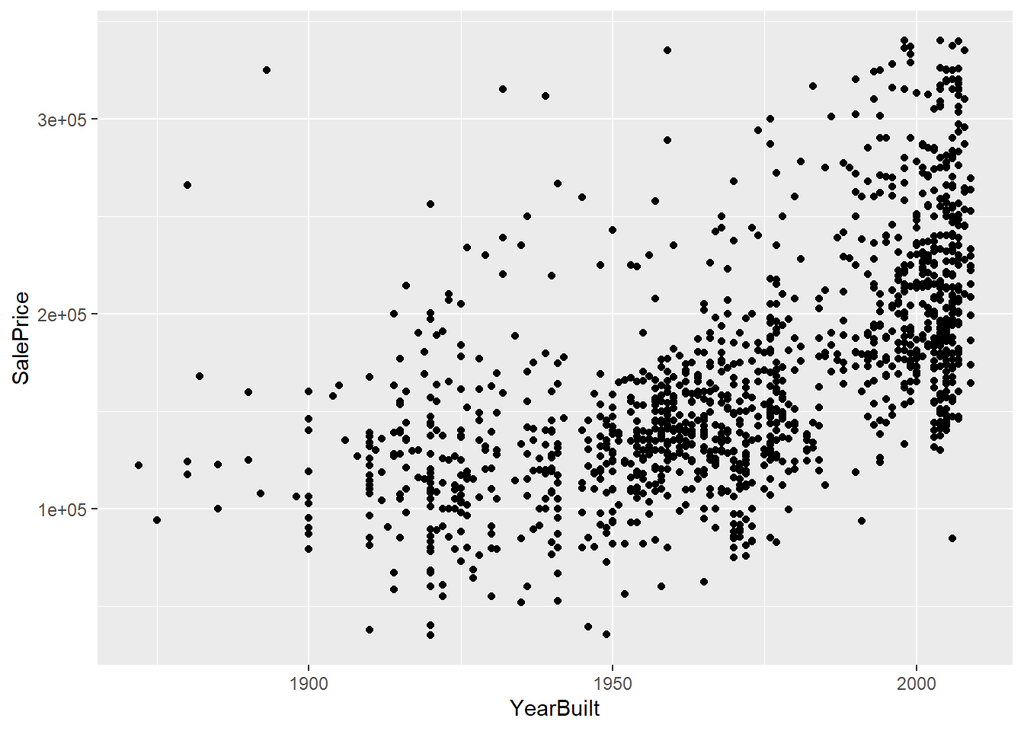

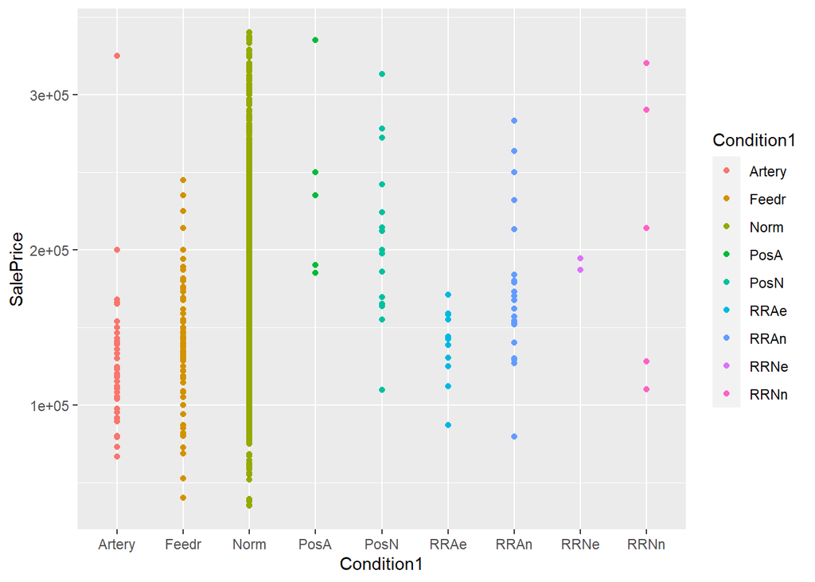

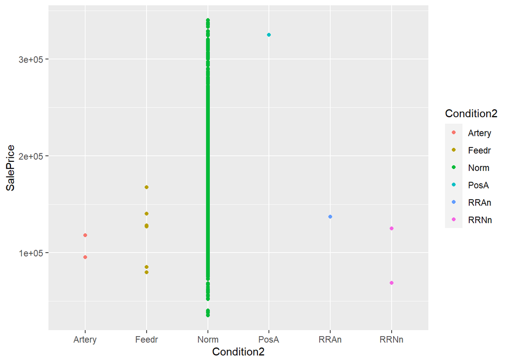

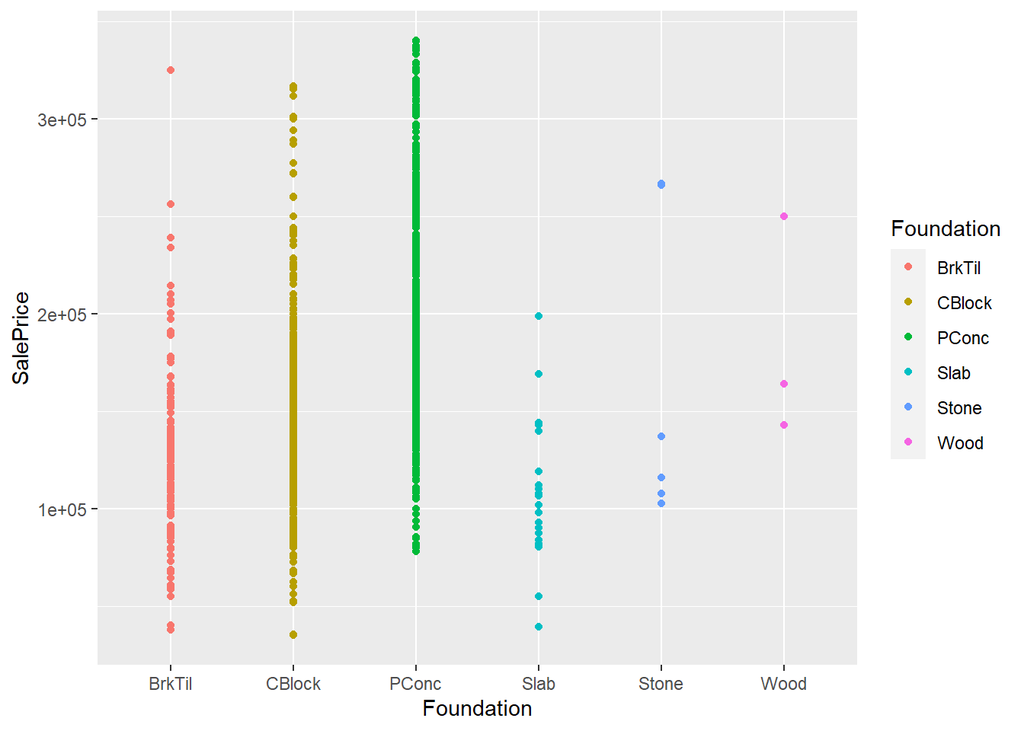

**head() from the modified subset data frame**

|  | MSSubClass | MSZoning | BldgType | HouseStyle | LotConfig | Neighborhood | Condition1 | Condition2 | Foundation | RoofStyle | RoofMatl | Exterior1st | Exterior2nd | ExterQual | HeatingQC | Electrical | LotFrontage | LotArea | OverallQual | OverallCond | YearBuilt | YearRemodAdd | MasVnrArea | MasVnrType | WoodDeckSF | OpenPorchSF | EnclosedPorch | BsmtFinSF1 | TotalBsmtSF | … |
| --- | --- | --- | --- | --- | --- | --- | --- | --- | --- | --- | --- | --- | --- | --- | --- | --- | --- | --- | --- | --- | --- | --- | --- | --- | --- | --- | --- | --- | --- | --- |
| 1 | 60 | RL | 1Fam | 2Story | Inside | CollgCr | Norm | Norm | PConc | Gable | CompShg | VinylSd | VinylSd | Gd | Ex | SBrkr | 65 | 8450 | 7 | 5 | 2003 | 2003 | 196 | BrkFace | 0 | 61 | 0 | 706 | 856 | … |
| 2 | 20 | RL | 1Fam | 1Story | FR2 | Veenker | Feedr | Norm | CBlock | Gable | CompShg | MetalSd | MetalSd | TA | Ex | SBrkr | 80 | 9600 | 6 | 8 | 1976 | 1976 | 0 | None | 298 | 0 | 0 | 978 | 1262 | … |
| 3 | 60 | RL | 1Fam | 2Story | Inside | CollgCr | Norm | Norm | PConc | Gable | CompShg | VinylSd | VinylSd | Gd | Ex | SBrkr | 68 | 11250 | 7 | 5 | 2001 | 2002 | 162 | BrkFace | 0 | 42 | 0 | 486 | 920 | … |
| 4 | 70 | RL | 1Fam | 2Story | Corner | Crawfor | Norm | Norm | BrkTil | Gable | CompShg | Wd Sdng | Wd Shng | TA | Gd | SBrkr | 60 | 9550 | 7 | 5 | 1915 | 1970 | 0 | None | 0 | 35 | 272 | 216 | 756 | … |
| 5 | 60 | RL | 1Fam | 2Story | FR2 | NoRidge | Norm | Norm | PConc | Gable | CompShg | VinylSd | VinylSd | Gd | Ex | SBrkr | 84 | 14260 | 8 | 5 | 2000 | 2000 | 350 | BrkFace | 192 | 84 | 0 | 655 | 1145 | … |
| 6 | 50 | RL | 1Fam | 1.5Fin | Inside | Mitchel | Norm | Norm | Wood | Gable | CompShg | VinylSd | VinylSd | TA | Ex | SBrkr | 85 | 14115 | 5 | 5 | 1993 | 1995 | 0 | None | 40 | 30 | 0 | 732 | 796 | … |

**correlation - R2 for various numeric variables with Sale Price**

```r
cor(housing_df$SalePrice, housing_df$LotArea)^2
```

```
## [1] 0.1528357
```

```r
cor(housing_df$SalePrice, housing_df$YearBuilt)^2
```

```
## [1] 0.3497324
```

```r
cor(housing_df$SalePrice, housing_df$YearRemodAdd)^2
```

```
## [1] 0.3085205
```

```r
cor(housing_df$SalePrice, housing_df$GrLivArea)^2
```

```
## [1] 0.4813659
```

```r
cor(housing_df$SalePrice, (housing_df$FullBath + (housing_df$HalfBath * 0.5)))^2
```

```
## [1] 0.390098
```

```r
cor(housing_df$SalePrice, housing_df$BedroomAbvGr)^2
```

```
## [1] 0.0397595
```

```r
cor(housing_df$SalePrice, housing_df$TotRmsAbvGrd)^2
```

```
## [1] 0.2298562
```

```r
cor(housing_df$SalePrice, housing_df$GarageArea)^2
```

```
## [1] 0.4066953
```

```r
cor(housing_df$SalePrice, housing_df$BsmtFinSF1)^2
```

```
## [1] 0.09712678
```

```r
cor(housing_df$SalePrice, housing_df$TotalBsmtSF)^2
```

```
## [1] 0.3482836
```

```r
cor(housing_df$SalePrice, housing_df$WoodDeckSF)^2
```

```
## [1] 0.08447678
```

```r
cor(housing_df$SalePrice, housing_df$OpenPorchSF)^2
```

```
## [1] 0.1118559
```

```r
cor(housing_df$SalePrice, housing_df$EnclosedPorch)^2
```

```
## [1] 0.02645305
```

**housing price prediction - multiple regression model creation and summary() of the models**

```
##
## Call:
## lm(formula = SalePrice ~ Neighborhood + RoofStyle + LotArea +
##     LotFrontage + OverallQual + OverallCond + YearBuilt + OpenPorchSF +
##     GrLivArea + TotRmsAbvGrd + GarageArea + TotalBsmtSF, data = housing_df)
##
## Residuals:
##     Min      1Q  Median      3Q     Max
## -123224   -9749     443   10078   73042
##
## Coefficients:
##                       Estimate Std. Error t value Pr(>|t|)
## (Intercept)         -1.072e+06  8.912e+04 -12.032  < 2e-16 ***
## NeighborhoodBlueste -1.235e+04  1.449e+04  -0.852 0.394427
## NeighborhoodBrDale  -1.582e+04  6.970e+03  -2.270 0.023365 *
## NeighborhoodBrkSide  1.272e+03  6.172e+03   0.206 0.836806
## NeighborhoodClearCr  5.621e+03  7.312e+03   0.769 0.442220
## NeighborhoodCollgCr -4.745e+03  5.156e+03  -0.920 0.357529
## NeighborhoodCrawfor  2.259e+04  6.254e+03   3.611 0.000316 ***
## NeighborhoodEdwards -1.115e+04  5.704e+03  -1.955 0.050794 .
## NeighborhoodGilbert -5.734e+03  5.536e+03  -1.036 0.300517
## NeighborhoodIDOTRR  -1.140e+04  6.572e+03  -1.734 0.083185 .
## NeighborhoodMeadowV -1.856e+04  6.980e+03  -2.659 0.007940 **
## NeighborhoodMitchel -1.229e+04  5.861e+03  -2.097 0.036167 *
## NeighborhoodNAmes   -9.416e+03  5.443e+03  -1.730 0.083889 .
## NeighborhoodNoRidge  1.595e+04  6.289e+03   2.537 0.011311 *
## NeighborhoodNPkVill -4.605e+03  8.139e+03  -0.566 0.571647
## NeighborhoodNridgHt  1.215e+04  5.628e+03   2.158 0.031096 *
## NeighborhoodNWAmes  -1.484e+04  5.669e+03  -2.618 0.008951 **
## NeighborhoodOldTown -1.371e+04  6.042e+03  -2.270 0.023372 *
## NeighborhoodSawyer  -1.154e+04  5.771e+03  -1.999 0.045841 *
## NeighborhoodSawyerW -4.365e+03  5.599e+03  -0.780 0.435785
## NeighborhoodSomerst  4.243e+03  5.291e+03   0.802 0.422704
## NeighborhoodStoneBr  1.046e+04  6.893e+03   1.518 0.129364
## NeighborhoodSWISU   -5.618e+03  6.946e+03  -0.809 0.418826
## NeighborhoodTimber  -4.514e+02  6.132e+03  -0.074 0.941340
## NeighborhoodVeenker  1.334e+04  7.994e+03   1.668 0.095475 .
## RoofStyleGable      -5.562e+03  8.816e+03  -0.631 0.528203
## RoofStyleGambrel     4.837e+02  1.058e+04   0.046 0.963526
## RoofStyleHip        -3.948e+03  8.855e+03  -0.446 0.655816
```

[output cut: 17 more lines]

```
## OverallCond7         4.267e+04  2.779e+04   1.535 0.124999
## OverallCond8         4.803e+04  2.786e+04   1.724 0.084957 .
## OverallCond9         5.513e+04  2.815e+04   1.958 0.050394 .
## YearBuilt            5.602e+02  4.410e+01  12.701  < 2e-16 ***
## OpenPorchSF          2.742e+01  9.050e+00   3.030 0.002497 **
## GrLivArea            5.162e+01  2.577e+00  20.031  < 2e-16 ***
## TotRmsAbvGrd        -2.592e+03  6.528e+02  -3.970 7.57e-05 ***
## GarageArea           2.563e+01  3.548e+00   7.223 8.66e-13 ***
## TotalBsmtSF          2.305e+01  1.813e+00  12.712  < 2e-16 ***
## ---
## Signif. codes:  0 '***' 0.001 '**' 0.01 '*' 0.05 '.' 0.1 ' ' 1
##
## Residual standard error: 19080 on 1290 degrees of freedom
## Multiple R-squared:  0.8993, Adjusted R-squared:  0.8952
## F-statistic: 217.4 on 53 and 1290 DF,  p-value: < 2.2e-16
```

> looking at model statistics iteratively, I refined the model a little bit from the beginning to include more relevant variables with higher impact on the prices and omit the ones having higher p values. Logistic regression is mainly useful for classification rather than predicting numeric values which can take any number of values, like house prices based on various factors. So, using only multiple linear regression model.

**Finalized model with little better predictive power**

```
##
## Call:
## lm(formula = SalePrice ~ Neighborhood + RoofStyle + LotArea +
##     LotFrontage + OverallQual + OverallCond + YearBuilt + OpenPorchSF +
##     GrLivArea + TotRmsAbvGrd + GarageArea + TotalBsmtSF + Exterior1st +
##     ExterQual + YearRemodAdd + MasVnrArea + MasVnrType + WoodDeckSF +
##     BsmtFinType1 + MSSubClass + MSZoning + HouseStyle + LotConfig +
##     Foundation + Condition1 + Condition2, data = housing_df)
##
## Residuals:
##     Min      1Q  Median      3Q     Max
## -108352   -8740     470    8553   68971
##
## Coefficients:
##                       Estimate Std. Error t value Pr(>|t|)
## (Intercept)         -1.167e+06  1.202e+05  -9.709  < 2e-16 ***
## NeighborhoodBlueste  1.106e+04  1.381e+04   0.800 0.423615
## NeighborhoodBrDale   7.856e+03  8.074e+03   0.973 0.330751
## NeighborhoodBrkSide  1.068e+03  6.743e+03   0.158 0.874225
## NeighborhoodClearCr -4.503e+03  6.950e+03  -0.648 0.517173
## NeighborhoodCollgCr -1.226e+04  5.206e+03  -2.355 0.018699 *
## NeighborhoodCrawfor  1.781e+04  6.234e+03   2.858 0.004341 **
## NeighborhoodEdwards -1.502e+04  5.784e+03  -2.598 0.009497 **
## NeighborhoodGilbert -1.190e+04  5.631e+03  -2.112 0.034849 *
## NeighborhoodIDOTRR  -5.261e+03  7.628e+03  -0.690 0.490469
## NeighborhoodMeadowV -1.740e+04  8.783e+03  -1.981 0.047775 *
## NeighborhoodMitchel -1.360e+04  5.916e+03  -2.299 0.021682 *
## NeighborhoodNAmes   -1.359e+04  5.591e+03  -2.431 0.015213 *
## NeighborhoodNoRidge  4.181e+03  6.289e+03   0.665 0.506282
## NeighborhoodNPkVill  1.108e+04  8.017e+03   1.382 0.167082
## NeighborhoodNridgHt  6.412e+03  5.472e+03   1.172 0.241542
## NeighborhoodNWAmes  -1.715e+04  5.787e+03  -2.964 0.003098 **
## NeighborhoodOldTown -1.173e+04  6.864e+03  -1.709 0.087626 .
## NeighborhoodSawyer  -1.125e+04  5.845e+03  -1.924 0.054588 .
## NeighborhoodSawyerW -6.873e+03  5.615e+03  -1.224 0.221181
## NeighborhoodSomerst -3.555e+03  6.703e+03  -0.530 0.596023
## NeighborhoodStoneBr  1.291e+04  6.460e+03   1.998 0.045978 *
## NeighborhoodSWISU   -7.453e+03  6.941e+03  -1.074 0.283126
## NeighborhoodTimber  -5.062e+03  6.013e+03  -0.842 0.400020
## NeighborhoodVeenker  1.364e+04  7.645e+03   1.784 0.074669 .
```

[output cut: 97 more lines]

```
## Condition1RRAn       1.971e+03  5.090e+03   0.387 0.698700
## Condition1RRNe      -1.295e+04  1.266e+04  -1.023 0.306586
## Condition1RRNn       1.849e+04  8.855e+03   2.088 0.037044 *
## Condition2Feedr      1.577e+04  1.725e+04   0.914 0.360901
## Condition2Norm       1.822e+04  1.507e+04   1.209 0.226885
## Condition2PosA       5.505e+04  2.695e+04   2.043 0.041312 *
## Condition2RRAn      -4.469e+02  2.315e+04  -0.019 0.984604
## Condition2RRNn       2.138e+04  1.959e+04   1.092 0.275233
## ---
## Signif. codes:  0 '***' 0.001 '**' 0.01 '*' 0.05 '.' 0.1 ' ' 1
##
## Residual standard error: 16710 on 1208 degrees of freedom
##   (6 observations deleted due to missingness)
## Multiple R-squared:  0.9275, Adjusted R-squared:  0.9198
## F-statistic: 119.9 on 129 and 1208 DF,  p-value: < 2.2e-16
```

> Finally, this derived model consists of about 27 predictor variables and produces little around 92.75% accuracy (Multiple R2 value). Adjusted R-squared value is around 92%. So, this differences is around 0.0075 a small value - less than 0.8%. Thus this model has slight variation in accuracy but can be a good representation of the large population of real world data with p-value of 15 zeroes prior to 22 i.e. very very small value and gives us good confidence that this model is a fairly accurate.

**95 % confidence interval**

```
##                             2.5 %        97.5 %
## (Intercept)         -1.402535e+06 -9.309811e+05
## NeighborhoodBlueste -1.604578e+04  3.816150e+04
## NeighborhoodBrDale  -7.984968e+03  2.369748e+04
## NeighborhoodBrkSide -1.216193e+04  1.429717e+04
## NeighborhoodClearCr -1.813716e+04  9.131933e+03
## NeighborhoodCollgCr -2.247117e+04 -2.044505e+03
## NeighborhoodCrawfor  5.583352e+03  3.004279e+04
## NeighborhoodEdwards -2.637222e+04 -3.677551e+03
## NeighborhoodGilbert -2.294365e+04 -8.478095e+02
## NeighborhoodIDOTRR  -2.022641e+04  9.703633e+03
## NeighborhoodMeadowV -3.463597e+04 -1.708544e+02
## NeighborhoodMitchel -2.520629e+04 -1.993373e+03
## NeighborhoodNAmes   -2.456143e+04 -2.621355e+03
## NeighborhoodNoRidge -8.157641e+03  1.652019e+04
## NeighborhoodNPkVill -4.645344e+03  2.681115e+04
## NeighborhoodNridgHt -4.324095e+03  1.714753e+04
## NeighborhoodNWAmes  -2.850400e+04 -5.797728e+03
## NeighborhoodOldTown -2.520137e+04  1.733163e+03
## NeighborhoodSawyer  -2.271507e+04  2.216383e+02
## NeighborhoodSawyerW -1.788886e+04  4.143267e+03
## NeighborhoodSomerst -1.670596e+04  9.596852e+03
## NeighborhoodStoneBr  2.307892e+02  2.557988e+04
## NeighborhoodSWISU   -2.107106e+04  6.164502e+03
## NeighborhoodTimber  -1.685829e+04  6.734431e+03
## NeighborhoodVeenker -1.360060e+03  2.863919e+04
## RoofStyleGable      -2.811654e+04  4.285366e+03
## RoofStyleGambrel    -2.291826e+04  1.597092e+04
## RoofStyleHip        -2.714253e+04  5.433244e+03
## RoofStyleMansard    -2.547990e+04  1.663326e+04
## LotArea              1.205986e+00  2.145739e+00
## LotFrontage         -4.086941e+01  2.767751e+01
## OverallQual2        -2.856396e+04  5.396923e+04
## OverallQual3        -3.250164e+04  4.316632e+04
## OverallQual4        -3.046610e+04  4.417662e+04
## OverallQual5        -2.915484e+04  4.586266e+04
## OverallQual6        -2.557269e+04  4.959055e+04
## OverallQual7        -1.530258e+04  6.011114e+04
## OverallQual8         2.203433e+03  7.812247e+04
## OverallQual9         3.359846e+04  1.113953e+05
```

[output cut: 76 more lines]

```
## FoundationStone     -6.005010e+03  2.342731e+04
## FoundationWood      -4.838734e+04 -8.103013e+03
## Condition1Feedr     -3.716615e+03  1.042208e+04
## Condition1Norm       1.585439e+03  1.343538e+04
## Condition1PosA      -3.064736e+03  2.780651e+04
## Condition1PosN      -9.596227e+02  2.029698e+04
## Condition1RRAe      -2.897784e+04 -4.610146e+03
## Condition1RRAn      -8.014816e+03  1.195584e+04
## Condition1RRNe      -3.778628e+04  1.188850e+04
## Condition1RRNn       1.112733e+03  3.585899e+04
## Condition2Feedr     -1.807634e+04  4.960833e+04
## Condition2Norm      -1.134419e+04  4.777844e+04
## Condition2PosA       2.173432e+03  1.079338e+05
## Condition2RRAn      -4.587019e+04  4.497647e+04
## Condition2RRNn      -1.705024e+04  5.981909e+04
```

**analysis of variance**

```r
anova(housing_mod_lm)
```

|  | Df | Sum Sq | Mean Sq | F value | Pr(>F) |
| --- | --- | --- | --- | --- | --- |
| Neighborhood | 24 | 2.582797e+12 | 107616533572 | 385.443936 | 0.000000e+00 |
| RoofStyle | 4 | 5.411693e+10 | 13529231625 | 48.456869 | 7.795362e-38 |
| LotArea | 1 | 3.230162e+11 | 323016227032 | 1156.928603 | 1.986252e-178 |
| LotFrontage | 1 | 3.585125e+09 | 3585124884 | 12.840635 | 3.526773e-04 |
| OverallQual | 9 | 7.009509e+11 | 77883436868 | 278.950617 | 1.380689e-287 |
| OverallCond | 8 | 3.362127e+10 | 4202658477 | 15.052420 | 3.444248e-21 |
| YearBuilt | 1 | 7.114085e+10 | 71140853904 | 254.801096 | 3.428817e-52 |
| OpenPorchSF | 1 | 2.873390e+10 | 28733899759 | 102.914553 | 2.902351e-23 |
| GrLivArea | 1 | 2.954421e+11 | 295442113882 | 1058.167991 | 3.146125e-167 |
| TotRmsAbvGrd | 1 | 1.090718e+10 | 10907182634 | 39.065627 | 5.671304e-10 |

[output cut: 17 more lines]

> Analysis of Variance statistics for the given model help to confirm the significance of selected variables for predicting housing prices.

**assumptions of independence durbin watson test**

```
##  lag Autocorrelation D-W Statistic p-value
##    1      0.03595457      1.928091   0.188
##  Alternative hypothesis: rho != 0
```

**assumptions of no multicolinearity**

```r
v <- vif(housing_mod_lm)

v
```

```
##                      GVIF Df GVIF^(1/(2*Df))
## Neighborhood 6.260709e+04 24        1.258722
## RoofStyle    2.251882e+00  4        1.106798
## LotArea      2.795870e+00  1        1.672085
## LotFrontage  1.462912e+00  1        1.209509
## OverallQual  1.062198e+02  9        1.295887
## OverallCond  1.891167e+01  8        1.201699
## YearBuilt    1.288356e+01  1        3.589367
## OpenPorchSF  1.429299e+00  1        1.195533
## GrLivArea    8.476724e+00  1        2.911481
## TotRmsAbvGrd 4.491318e+00  1        2.119273
## GarageArea   2.037311e+00  1        1.427344
## TotalBsmtSF  5.659159e+00  1        2.378899
## Exterior1st  5.802099e+01 14        1.156073
## ExterQual    1.102684e+01  3        1.491907
## YearRemodAdd 2.884558e+00  1        1.698399
## MasVnrArea   2.506809e+00  1        1.583291
## MasVnrType   4.698417e+00  3        1.294172
## WoodDeckSF   1.273914e+00  1        1.128678
## BsmtFinType1 1.821869e+01  6        1.273629
## MSSubClass   7.312065e+07 14        1.909231
## MSZoning     4.599684e+01  4        1.613768
## HouseStyle   1.112154e+06  7        2.703142
## LotConfig    1.998494e+00  4        1.090405
## Foundation   2.881236e+01  5        1.399452
## Condition1   4.620963e+00  8        1.100388
## Condition2   5.605796e+00  5        1.188129
```

```r
1/v
```

```
##                      GVIF         Df GVIF^(1/(2*Df))
## Neighborhood 1.597263e-05 0.04166667       0.7944569
## RoofStyle    4.440730e-01 0.25000000       0.9035076
## LotArea      3.576705e-01 1.00000000       0.5980556
## LotFrontage  6.835682e-01 1.00000000       0.8267818
## OverallQual  9.414441e-03 0.11111111       0.7716725
## OverallCond  5.287741e-02 0.12500000       0.8321553
## YearBuilt    7.761832e-02 1.00000000       0.2786006
## OpenPorchSF  6.996435e-01 1.00000000       0.8364470
## GrLivArea    1.179701e-01 1.00000000       0.3434678
## TotRmsAbvGrd 2.226518e-01 1.00000000       0.4718599
## GarageArea   4.908430e-01 1.00000000       0.7006019
## TotalBsmtSF  1.767047e-01 1.00000000       0.4203626
## Exterior1st  1.723514e-02 0.07142857       0.8649974
## ExterQual    9.068780e-02 0.33333333       0.6702829
## YearRemodAdd 3.466736e-01 1.00000000       0.5887899
## MasVnrArea   3.989135e-01 1.00000000       0.6315960
## MasVnrType   2.128376e-01 0.33333333       0.7726950
## WoodDeckSF   7.849822e-01 1.00000000       0.8859922
## BsmtFinType1 5.488869e-02 0.16666667       0.7851577
## MSSubClass   1.367603e-08 0.07142857       0.5237710
## MSZoning     2.174063e-02 0.25000000       0.6196679
## HouseStyle   8.991560e-07 0.14285714       0.3699398
## LotConfig    5.003769e-01 0.25000000       0.9170904
## Foundation   3.470732e-02 0.20000000       0.7145656
## Condition1   2.164051e-01 0.12500000       0.9087705
## Condition2   1.783868e-01 0.20000000       0.8416592
```

```r
t <- 0

for(i in 1:24)
{
    t = t + v[i, 3]
}

t/24
```

```
## [1] 1.654531
```

> Based on (Field, Miles, and Field 2012) book

> Mean of VIF values is little bit above 1, indicates our model might be slightly biased and may be needs to consider additional predictor variables or more cleaning of data needed or additional / larger size of data is needed. Current data size after filtering became 1344 records.

**plot() and hist() function**

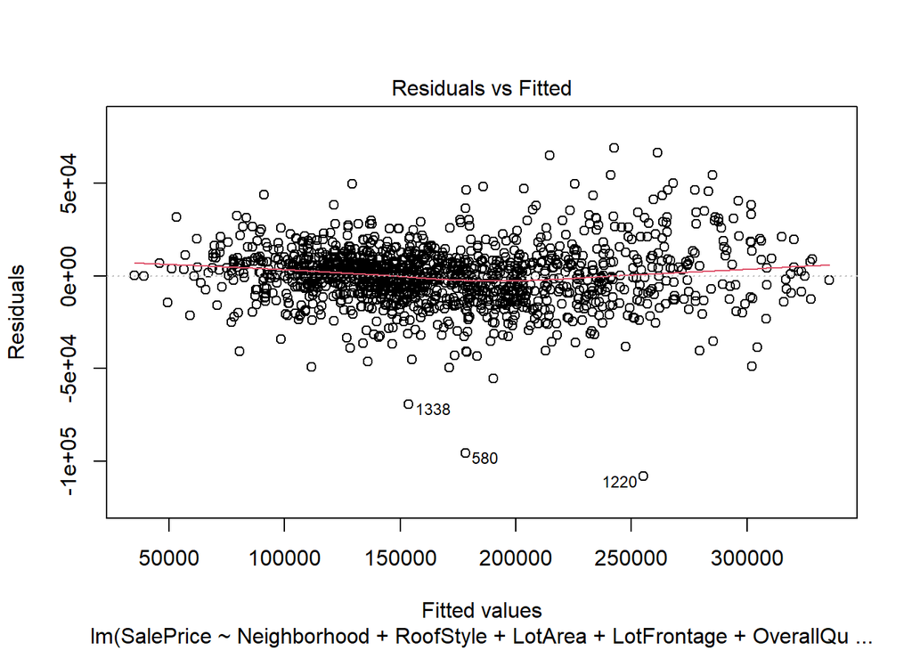

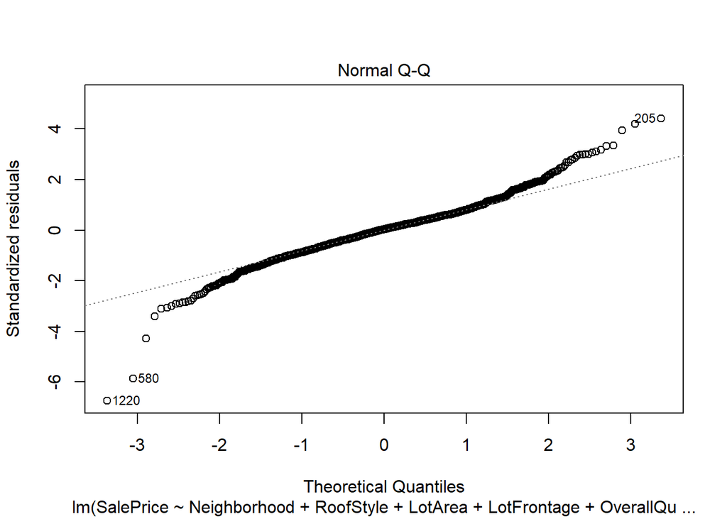

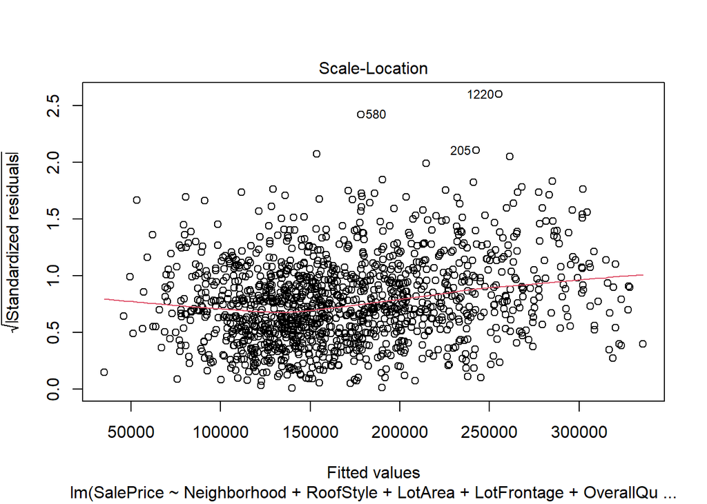

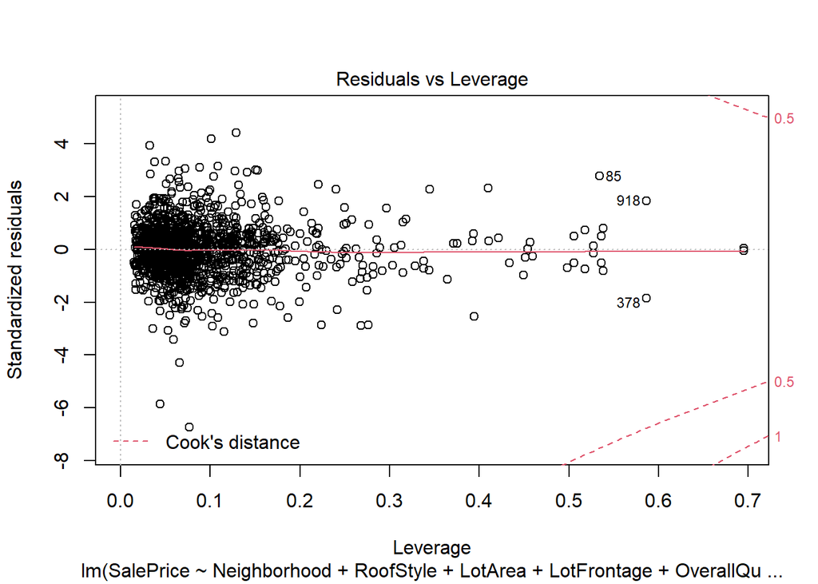

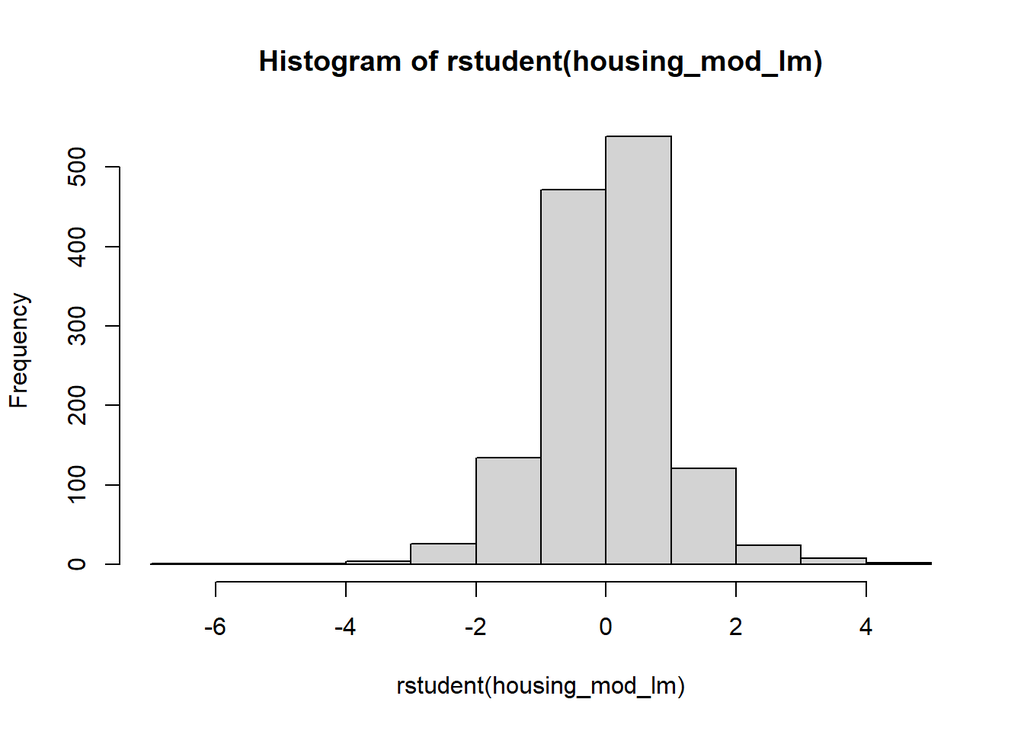

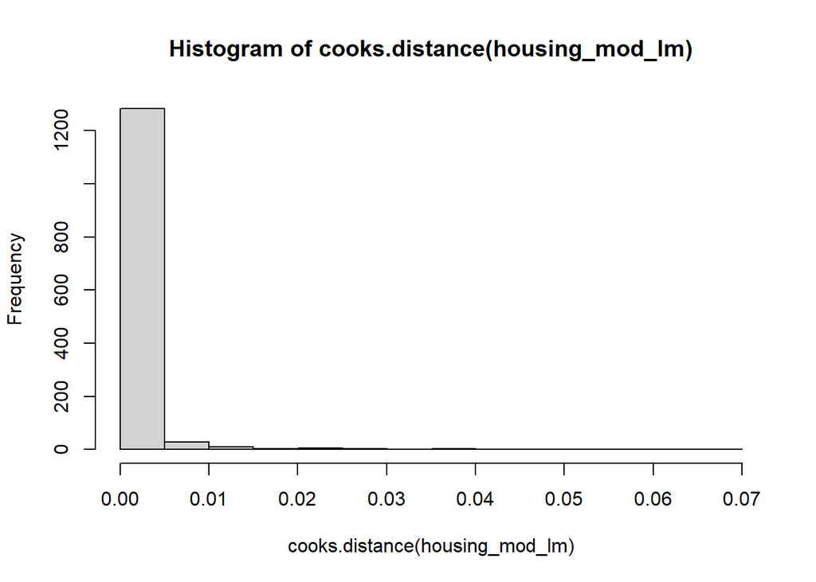

> As we can see, fitted line on Residuals vs Fitted values, is close to 0 residuals line and as we go towards the lower and upper extremes, the line seems to deviate from ideal fitted line. It can be improved with possibly more number of records for model creation and possibly reducing some of outliers on the lower and upper ends. Also in this plot, residuals in our model shows a fairly random pattern, which is indicative of situation in which the assumptions of linearity, randomness and homoscedasticity have been met.

> Normal Q-Q plot shows most of the records fall between 2 standard deviations of the mean, mostly along the straight line fit and thus the model is a good representation of the data, for predictions.

> Histogram of Studentized residuals also shows a close to normal distribution up to 2 standard deviations around mean, although we can confirm the same cases earlier that we might be having some level of outliers / skewness in the distribution which might be causing slight deviation of the residuals from the straight line.

> All of the records have Cook’s distance less than 1, hence we should be good about the model.

> Looking at the model, it is fairly close representation of the sample and a generalizable model to the larger population. It can be improved further by deleting outliers for model building purpose. We may need to consider additional predictor variables or more cleaning of data is needed. Another way, perhaps could be finding additional / larger size of data, which can smoothen out the normal distribution even further and help improve accuracy of the model. Current data size after filtering became 1344 records. So, possibly a little larger data size could help.

**Conclusion**

> Overall, people interested in buying a house need to consider not only the basic factors like area / size, number of rooms / bathrooms, neighborhood, garage area, year of initial built but also the overall quality of the construction, Foundations well Roof types, when the house is remodeled, if applicable and Exteriors, open areas and masonry work along with Basement finishing. Based on different geographic locations, the proximity to key essentials and amenities like hospitals, schools, shopping malls, commercial buildings etc. are also important.

## References

Field, A., J. Miles, and Z. Field. 2012. *Discovering Statistics Using R*. SAGE Publications. https://books.google.com/books?id=wd2K2zC3swIC.